# Homework 3

Devin Bunch

5/18/2021

## Part A: Problem Sets

**1. On the set of axes above with the abatement level on the x-axis and the marginal cost on the y-axis, draw for each country the cost of pollution abatement. Carefully label the intercept, and indicate the slope.**

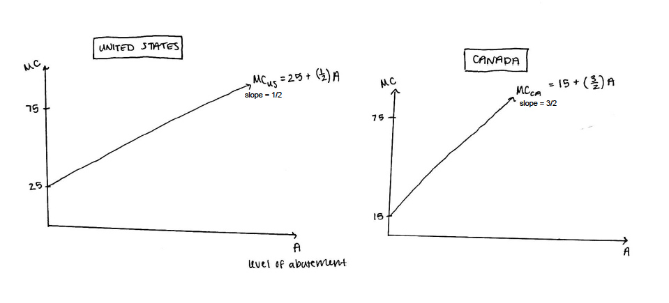

```r
#include a png file of my work
q1 <- knitr::include_graphics("/Users/devin3/Desktop/q1.png")
q1
```

**2. Suppose that the U.S. produces a total of 280 tons CO2emissions per year, while Canada emits 260 tons. What is the level of abatement the U.S. needs to comply with to satisfy the Kyoto Protocol? How about Canada?What is the marginal cost paid by US firms to reduce carbon emissions by the targeted amount? What is the marginal cost for Canada?**

Suppose the United states produces 280 tons of carbon emissions per year and Canada image 260 tons per year. We want to know the level of abatement the US needs to comply with to satisfy the Kyoto Protocol. To find this, we note that the target goal level given by the protocol is 200 tons annually. Thus, The US must abate 80 tons of CO2 emissions annually to meet the protocols requirements. For Canada, we see they’ll need to abate 60 tons of CO2 to also be at a level of 200 tons produced annually. Now, we want to find the marginal cost paid by US firms to reduce emissions required by the Kyoto Protocol.

The marginal cost for America to abate 80 tons is $65. The marginal cost for Canada to abate 60 tons is $105.

**Now, assume that the market price per ton of CO2is 75 dollars, and that one pollution allowance traded on this market corresponds to one ton of CO2. Thus, any polluting firm can purchase a permit to emit 1 ton of CO2at the rate of 75 dollars. Both countries take this price as given.**

**3. At the on-going market price of carbon, the US is willing to abate **100** tons of CO2. Given its targeted abatement level, the US has a _____surplus____ (surplus/deficit) of pollution permits in the3www2 amount of ____20____ tons of CO2.**

**4.At the on-going market price of carbon, Canada is willing to abate *40* tons of CO2. Given its targeted abatement level, Canada has a ____deficit____ (surplus/deficit) of pollution permits in the amount of *20* tons of CO2.**

**5.Does the US gain from trading (i.e., buying/selling) permits on the world carbon trading market? Calculate the gains/losses from participating in the market for pollution permits. Indicate on the MC graph previously drawn the area corresponding to the calculated gains/losses from trade.**

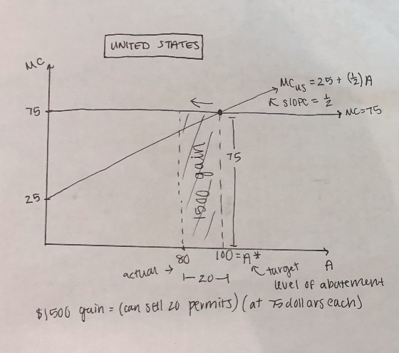

```r
#include a png file of my work
#resources used:lecture 10--cap and trade :)
america <-  knitr::include_graphics("/Users/devin3/Desktop/us.png")
america
```

**6. How about Canada, does it gain from trading (i.e., buying/selling) permits on the world carbon trading market? Calculate the gains/losses from participating in the market for pollution permits. Indicate on the MC graph previously drawn the area corresponding to the calculated gains/losses.**

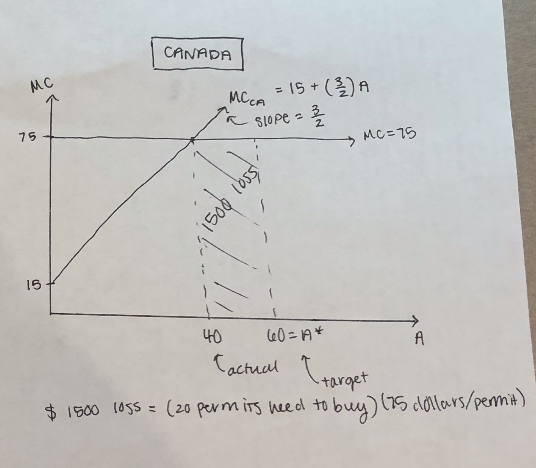

```r
#include a png file of my work
canada <-  knitr::include_graphics("/Users/devin3/Desktop/ca.png")
canada
```

Canada loses from buying permits on the world carbon trading market. Specifically, they lose $1,500$ USD because the country polluted a total amount of 260 tons of $CO_2$ and did not abate enough greenhouse gas emissions to meet the Kyoto Protocol’s requirement level of 200 tons. Although they optimally abate 40 tons of $CO_2$ on their own, Canada still exceeded the 200 limit by 20 tons(from the Kyoto Protocol). They are then forced to purchase 20 permits to compensate, at a cost of 75 USD per permit. Basic algebra tells us that Canada is losing precisely $(20 permits)(75 dollars per permit) = 1,500$.

**7.Draw an Environmental Kuznets Curvecarefully labeling the axes. Based on the discussion in this problem, where on the curve would you locate the U.S.? How about Canada?**

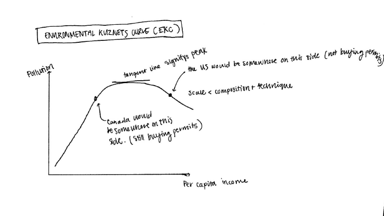

```r
#include a png file of my work
kc <- knitr::include_graphics("/Users/devin3/Desktop/curve.png")
kc
```

**8.Calculate the Cumulative Share of Income for each country, and fill the empty column in the table.**

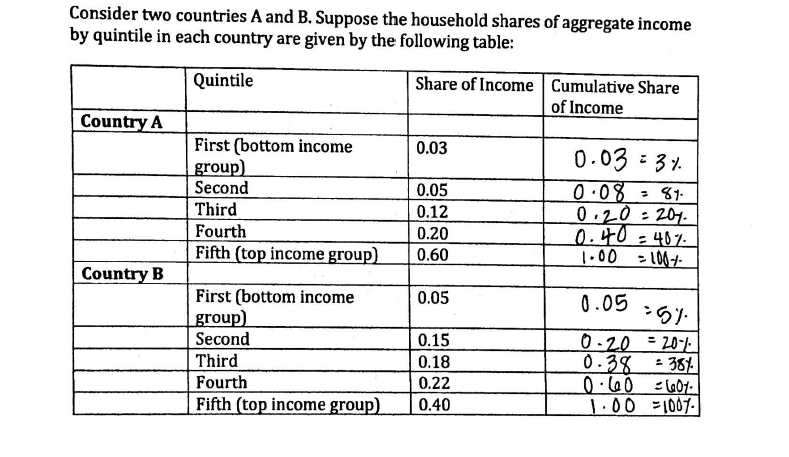

```r
#include a png file of my work
tab <-  knitr::include_graphics("/Users/devin3/Desktop/table.png")
tab
```

**9.Draw the Lorenz curve for each country. Clearly label the axes.**

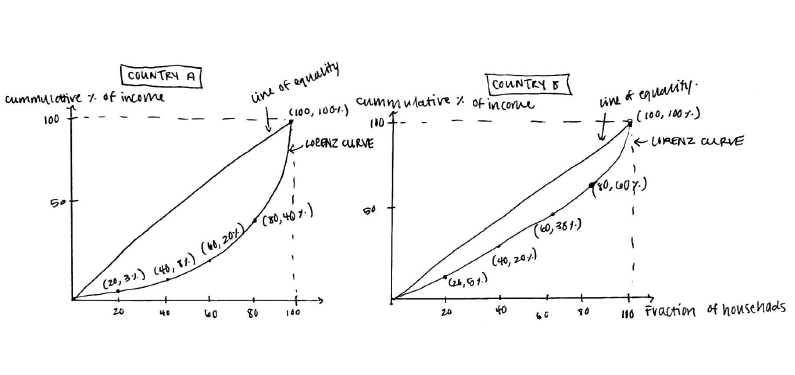

```r
#include a png file of my work
lorenz <- knitr::include_graphics("/Users/devin3/Desktop/lorenz.png")
lorenz
```

**10.What is a Gini coefficient? Which country do you think will have a higher Gini Coefficient? (Note: no need for mathematical calculation, just explanation)**

The Gini coefficient is the ratio between [the area under the line of equality, shown by area A,] and the area below the Lorenzo curve, given by area B plus the area A. Thus, the gini coefficient G is configured by $G = A/(A + B)$ We can estimate that country A will have a higher gini coefficient when we look at the denominator and sizes of the areas.

## **Part B: READING (4 questions x 10 points each = 40 points)**

*Read the attached short article from The Economist magazine. Address the following questions.*

**11.What is the Kyoto Protocol? When does it become outdated? What is the current state of international negotiations on climate change?**

Global warming is a global harm that requires global governance of the United Nations to use International Environmental Agreements to slow environmental degradation around the world. In response to the concerning level of of carbon dioxide emissions, representatives from various nations met in Kyoto, Japan, to discuss nonbinding targets for reducing greenhouse gas emissions. In December of 1997, 160 countries ratified this agreement to last for 5 years, not including the US.

The Kyoto Protocol is a legally binding mitigation effort designed to reduce carbon emissions. Developed and developing countries got together to plan an agreement wherein countries committed to global climate change policies that were designed to slow down the growth of $CO_2$ emissions. Countries individually set up targets to reduce greenhouse emissions over a 5 year interval, but developed countries all had a higher baseline reduction target: Developed countries have obligations to reduce emissions by 5.2% relative to base 1990 year levels. Developing countries had no obligations to reduce emissions (including China–rising to become the biggest polluter in years to come after 1997). In the more developed countries, larger, stringent targets were assigned: the targets range from an 8% carbon emission reduction in the European Union to a not required 0% reduction for Russia.

Because the Kyoto Protocol failed to include the developing countries in the first enactment, after 5 years when it expired in 2012, they reconvened to resign the Kyoto Protocol. However, upon further discussion and analysis of the first five year impact of Kyoto on greenhouse gas emissions, they realized it was a failed attempt. At the end of these five years, the developed countries whom has set ambitious carbon reduction targets were found to have not complied to the regulations and fell behind in reducing their part of carbon dioxide. So in 2012, the Kyoto Protocol’s impact was considered close to zero because countries did not meet their $CO_2$ reduction goals. It was not resigned.

**12.What are the main reasons why countries hesitate to commit to multilateral environmental agreements?**

Well, we know that the US did not sign the first five year cycle of the Kyoto Protocol–and our article gives us reasons for the rejection. U.S. officials were against Kyoto because although evidence for global warning is strong, they did not know the effect policy actions would have. For large carbon emitting world powers, meeting Kyoto targets would negatively affect their economy, since they would be forced to pay more to reach target abatement levels. Kyoto also failed to include the developing countries, mainly China and India, whom were on their way to becoming the biggest contributors to greenhouse gasses. India and China were able to argue successfully that they were not responsible for most of the past emissions, so they should be exempt for now from changing their emissions. At the time, it was accepted, but now it’s obvious they are some of the most problematic countries regarding pollution. The U.S. argues against exempting developing countries because if carbon-intensive industry moves to India, China, carbon output does not drop due to carbon leakage. Since there are other ways to pursue reductions in greenhouse gas emissions, countries hesitate to commit to year long, expensive policies that do not require the biggest polluters to participate.

**13.What are possible ways to overcome the impasse in reducing greenhouse gas emissions?**

Since the Kyoto Protocol was considered a fail in reducing greenhouse gas emissions, some of the most powerful developing countries–China, Brazil, South Africa and India–discussed how to move forward. The impasse here is the fact that rich countries will fail in their emission-curbing commitment given another round of Kyoto Protocol. Furthermore, the protocol excluded any developing country from having to participate. For those reasons, America never signed the original agreement of the Kyoto Protocol–excluding themselves from the overall reduction of carbon emissions. To get around this, the leading countries met in Cancun to discuss how thresholds can be individually met around the globe in an aggregation of effort to reduce pollution. This is because without America’s (and China’s) participation, the world climate problem will remain unsolved. Choosing more modest targets for the abatement level would encourage these bigger world countries to join, participate, and actually have a feasible goal in sight for reduction (they could meet the goals this time around).

**14.Explain/discuss your personal opinion about what is a feasible and efficient measure to reduce the carbon footprint. (Note: you can use external references to support your answer)**

Currently worldwide, not everyone is on the same level of abatement–and not everyone can agree upon the most optimal abatement level desired. Countries don’t even universally agree the Pollution Haven exists. However, pollution concentration is an international problem–so we are forced to discuss how to regulate, and abate $CO_2$ emissions. We’ve seen the Kyoto Protocol failed in making any impact against the concentration of carbon in the atmosphere–surprising results. When we considered why this happened, we see it’s because abatement goals were too far fetched, and also countries were not held responsible enough for not meeting these goals. It’s also worth mentioning that America was not forced to sign the Kyoto Protocol–which implies they will not be making those active efforts towards abatement. Although I acknowledge the fact that reducing global emissions is a tough caveat, I personally think that obligating countries through cap and trade and laxidazicle policies like the Kyoto Protocol will never work to physically abolish carbon emissions to a safe level. There’s too much room for error and for countries to either not join agreements, or to not meet the agreement’s demand. Given these roadblocks, we can consider alternative solutions. Jagdish Bhagwati, from Columbia University, argues in favor of a Superfund to reduce carbon emissions on a global scale. This superfund would suggest rich nations to agree to pay damage into this trust for being the main contributors of greenhouse gases in the past. It also would be used to research alternatives to fossil fuels and provide developing countries with pollution reducing devices. Rich countries would be encouraged to participate given the fact that most technology is created in their land–and would thus stimulate their own economic growth alongside saving the environment.

## **Part C: For EC 582 students ONLY (50 points)**

*This is a data exercise where you will analyze the determinants of greenfield FDI, as well as the decision of firms to reach foreign consumers via FDI versus exports. The dataset for this exercise contains information on the total number of FDI projects that a source country (i.e., origin) undertakes in a destination country (i.e., host economy). It also contains information on the total value of trade between sourceand host countries.The full dataset is available on Canvas under the name of “fdi.dta”and a description of all the variables is provided at the end of this assignment. You can use STATA, R or any other statistical package you are familiar with to answer the questions below.When submitting your answers, please make sure to attach a copy of your code/do-file and a copy of your log file or R output (all in one pdf document that includes your homework answers).Using the available dataset, please answer the following questions:*

```r
#Frist we need to load our packages
library(pacman)
pacman::p_load(tidyverse, readr, haven, sandwich, skimr, stargazer)
```

Now we can move forward with our analysis!

```r
#we want to import our data into R markdown, using the haven package to open a stata .dta file
fdi_df <- read_dta("fdi.dta")

#Check it out
fdi_df %>% skim()
```

Data summary

| Name | Piped data |
| --- | --- |
| Number of rows | 23181 |
| Number of columns | 18 |
| _______________________ |  |
| Column type frequency: |  |
| character | 4 |
| numeric | 14 |
| ________________________ |  |
| Group variables | None |

**Variable type: character**

| skim_variable | n_missing | complete_rate | min | max | empty | n_unique | whitespace |
| --- | --- | --- | --- | --- | --- | --- | --- |
| sourcecountry | 0 | 1 | 2 | 27 | 0 | 148 | 0 |
| sourceiso | 0 | 1 | 3 | 3 | 0 | 148 | 0 |
| hostcountry | 0 | 1 | 2 | 18 | 0 | 99 | 0 |
| hostiso | 0 | 1 | 3 | 3 | 0 | 99 | 0 |

**Variable type: numeric**

| skim_variable | n_missing | complete_rate | mean | sd | p0 | p25 | p50 | p75 | p100 | hist |
| --- | --- | --- | --- | --- | --- | --- | --- | --- | --- | --- |
| year | 0 | 1 | 2.009360e+03 | 3.620000e+00 | 2.003000e+03 | 2.006000e+03 | 2.009000e+03 | 2.012000e+03 | 2.015000e+03 | ▆▅▇▆▇ |
| fdi_projects | 0 | 1 | 6.570000e+00 | 1.892000e+01 | 1.000000e+00 | 1.000000e+00 | 2.000000e+00 | 5.000000e+00 | 4.200000e+02 | ▇▁▁▁▁ |
| capitalinvestment | 0 | 1 | 3.939300e+02 | 1.202370e+03 | 0.000000e+00 | 1.510000e+01 | 6.130000e+01 | 2.603300e+02 | 3.260110e+04 | ▇▁▁▁▁ |
| tradevalue | 0 | 1 | 6.119580e+03 | 1.957989e+04 | 0.000000e+00 | 2.800000e+02 | 1.140570e+03 | 4.300070e+03 | 4.818808e+05 | ▇▁▁▁▁ |
| border | 0 | 1 | 8.000000e-02 | 2.800000e-01 | 0.000000e+00 | 0.000000e+00 | 0.000000e+00 | 0.000000e+00 | 1.000000e+00 | ▇▁▁▁▁ |
| comlang | 0 | 1 | 1.600000e-01 | 3.700000e-01 | 0.000000e+00 | 0.000000e+00 | 0.000000e+00 | 0.000000e+00 | 1.000000e+00 | ▇▁▁▁▂ |
| comcol | 0 | 1 | 5.000000e-02 | 2.300000e-01 | 0.000000e+00 | 0.000000e+00 | 0.000000e+00 | 0.000000e+00 | 1.000000e+00 | ▇▁▁▁▁ |
| dist | 0 | 1 | 5.789720e+03 | 4.373710e+03 | 1.317600e+02 | 1.738870e+03 | 5.067100e+03 | 8.951170e+03 | 1.951656e+04 | ▇▃▅▁▁ |
| gdp_source | 0 | 1 | 1.861503e+12 | 3.331819e+12 | 5.085054e+08 | 2.422303e+11 | 5.515520e+11 | 2.052807e+12 | 1.803665e+13 | ▇▁▁▁▁ |
| gdp_host | 0 | 1 | 1.237623e+12 | 2.775104e+12 | 2.023324e+09 | 9.913030e+10 | 2.837032e+11 | 1.141268e+12 | 1.803665e+13 | ▇▁▁▁▁ |
| gdpcap_source | 0 | 1 | 3.396402e+04 | 2.311240e+04 | 2.665900e+02 | 1.332429e+04 | 3.615269e+04 | 4.734680e+04 | 1.166129e+05 | ▇▇▅▁▁ |
| gdpcap_host | 0 | 1 | 2.098195e+04 | 2.084487e+04 | 1.197900e+02 | 3.926170e+03 | 1.146038e+04 | 3.830984e+04 | 1.166129e+05 | ▇▃▁▁▁ |
| fta | 0 | 1 | 3.900000e-01 | 4.900000e-01 | 0.000000e+00 | 0.000000e+00 | 0.000000e+00 | 1.000000e+00 | 1.000000e+00 | ▇▁▁▁▅ |
| entry_cost_d | 0 | 1 | 1.680000e+01 | 4.230000e+01 | 1.000000e-01 | 2.100000e+00 | 7.500000e+00 | 1.690000e+01 | 1.316400e+03 | ▇▁▁▁▁ |

```r
names(fdi_df)
```

```
##  [1] "year"              "sourcecountry"     "sourceiso"
##  [4] "hostcountry"       "hostiso"           "fdi_projects"
##  [7] "capitalinvestment" "tradevalue"        "border"
## [10] "comlang"           "comcol"            "dist"
## [13] "gdp_source"        "gdp_host"          "gdpcap_source"
## [16] "gdpcap_host"       "fta"               "entry_cost_d"
```

```r
#we see we have 18 variable columns, and 23181 observation rows.
```

The dataset “fdi.dta” is a panel dataset that contains n=23,181 observations on the number and value of foreign directinvestment projectsbetween 100+ countries over the period 2003-2015.For each source and destination country pair observed in a given year, the dataset reports information on the following variables:

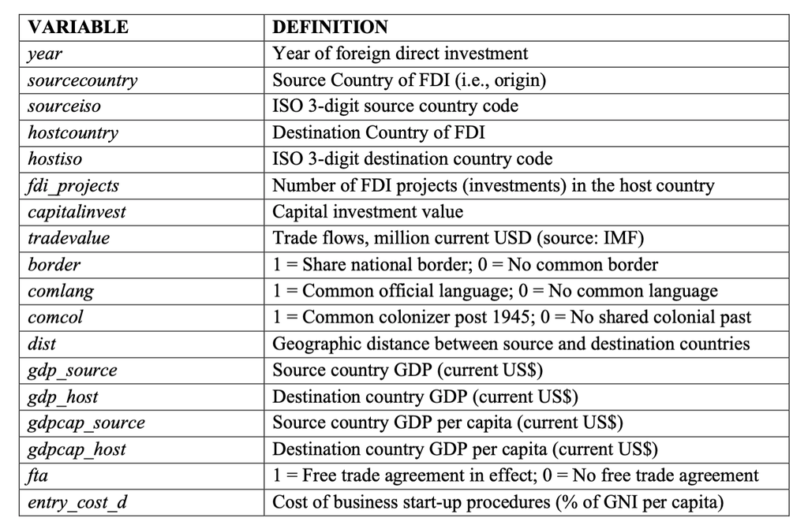

```r
#add description table from assignment document
knitr::include_graphics("/Users/devin3/Desktop/variables.png")
```

**15.(10points) Plot the total number of FDI projects that took place in a year over the sample period 2003-2015. You can use a box diagram or a trend line, whichever graphing tool provides the best visualization of the data. What can you say about the trend in global greenfield FDI over time?**

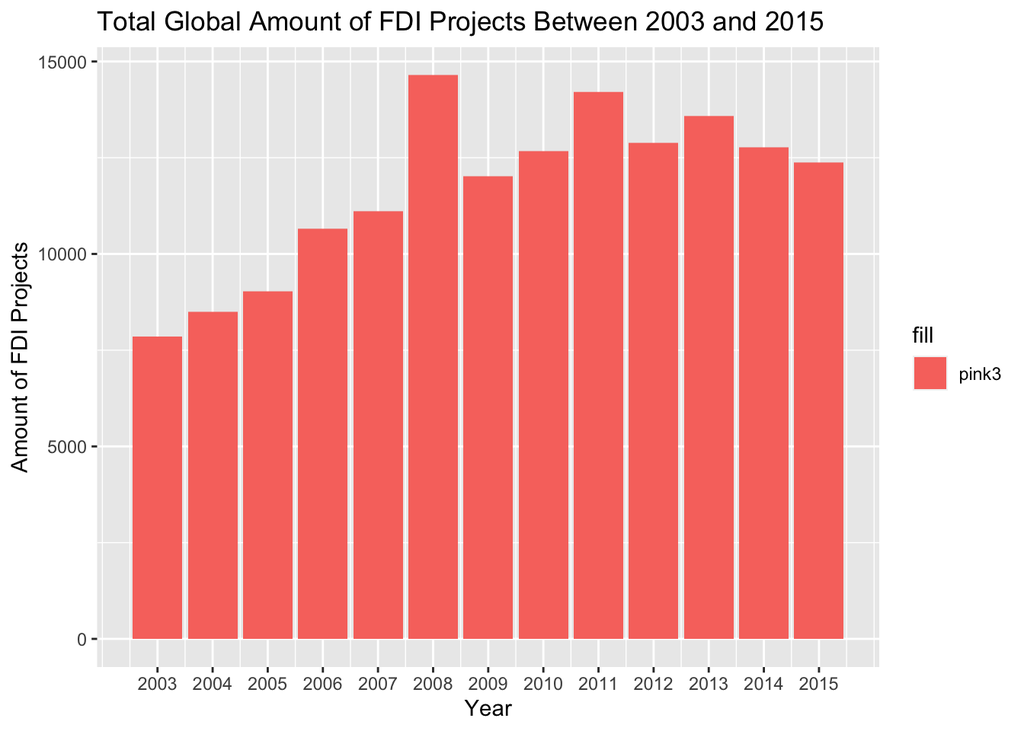

```r
#make a subset for the given year time frame
fdi_15 <- fdi_df %>% filter(year > 2002 & year < 2016)

ggplot(fdi_15, aes(year, fdi_projects)) + geom_col(aes(fill = "pink3"))  + labs(x = "Year", y = "Amount of FDI Projects", title = "Total Global Amount of FDI Projects Between 2003 and 2015") + scale_x_continuous(breaks = seq(2003, 2015, 1))
```

Globally, we see less variation in FDI project amounts than we do for just the US seen below. The year 2008 had the most amount of FDI projects out of all the years. Although there has been a general increase in FDI projects, it’s only just about less than doubled since 2003. It seems like globally, we stay around a rate of 12000 FDI projects annually.

**Redo the graph using only the FDI projects for which the USA is the source country(i.e., US outward FDI).**

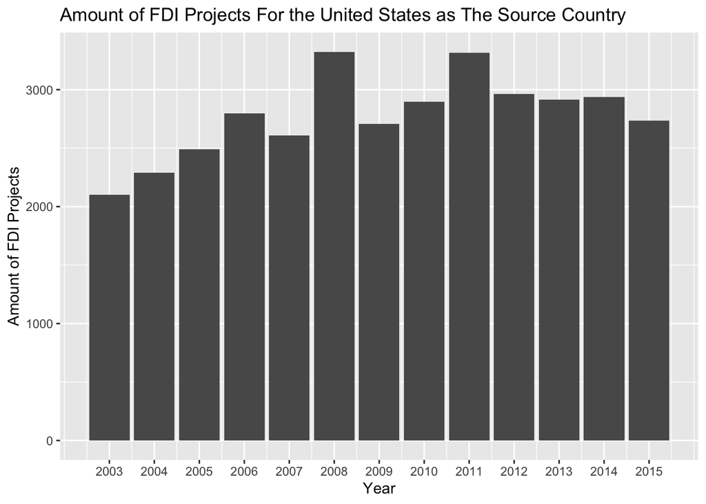

```r
#subset our data accordingly
fdi_15_source <- fdi_15 %>% filter(sourcecountry == "United States")

#plot
ggplot(fdi_15_source, aes(year, fdi_projects)) + geom_col() + labs(x = "Year", y = "Amount of FDI Projects", title = "Amount of FDI Projects For the United States as The Source Country") + scale_x_continuous(breaks = seq(2003, 2015, 1))
```

**Redo the graph for US inward FDI (i.e., USA is the host country).**

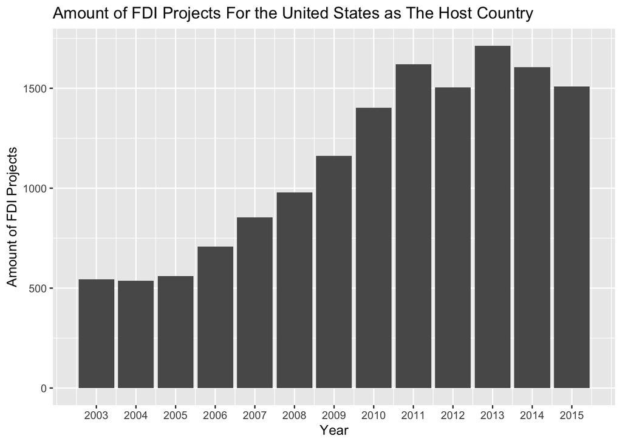

```r
#subset our data accordingly
fdi_15_host <- fdi_15 %>% filter(hostcountry == "United States")

#plot
ggplot(fdi_15_host, aes(year, fdi_projects)) + geom_col() + labs(x = "Year", y = "Amount of FDI Projects", title = "Amount of FDI Projects For the United States as The Host Country") + scale_x_continuous(breaks = seq(2003, 2015, 1))
```

**What can you say about the trends in US greenfield FDI?**

From our plots, we can see that overall, the trend for the amount of FDI projects is increasing. They increased the most in magnitude between the years 2005 and 2011–which implies there was the biggest influx of new FDI projects in that time frame.

**16.(5points) Construct the natural log for the following variables:**

```r
#since R has a base function of the natural log for log, we can use mutate and log to make our new variables
fdi_df <- fdi_df %>% mutate(ln_trade = log(tradevalue),
                            ln_gdp_o = log(gdp_source),
                            ln_gdp_d = log(gdp_host),
                            ln_pcgdp_gap = log(gdpcap_source/gdpcap_host),
                            ln_dist = log(dist),
                            ln_entrycost = log(entry_cost_d),
                            ratio_fdi_trade = fdi_projects/tradevalue)
#print it out
fdi_df
```

```
## # A tibble: 23,181 x 25
##     year sourcecountry sourceiso hostcountry hostiso fdi_projects
##    <dbl> <chr>         <chr>     <chr>       <chr>          <dbl>
##  1  2003 UAE           ARE       Australia   AUS                1
##  2  2003 UAE           ARE       Austria     AUT                2
##  3  2003 UAE           ARE       Bangladesh  BGD                1
##  4  2003 UAE           ARE       Switzerland CHE                1
##  5  2003 UAE           ARE       China       CHN                2
##  6  2003 UAE           ARE       Egypt       EGY                2
##  7  2003 UAE           ARE       Spain       ESP                1
##  8  2003 UAE           ARE       Finland     FIN                1
##  9  2003 UAE           ARE       UK          GBR                1
## 10  2003 UAE           ARE       India       IND                3
## # … with 23,171 more rows, and 19 more variables: capitalinvestment <dbl>,
## #   tradevalue <dbl>, border <dbl>, comlang <dbl>, comcol <dbl>, dist <dbl>,
## #   gdp_source <dbl>, gdp_host <dbl>, gdpcap_source <dbl>, gdpcap_host <dbl>,
## #   fta <dbl>, entry_cost_d <dbl>, ln_trade <dbl>, ln_gdp_o <dbl>,
## #   ln_gdp_d <dbl>, ln_pcgdp_gap <dbl>, ln_dist <dbl>, ln_entrycost <dbl>,
## #   ratio_fdi_trade <dbl>
```

**17.(7points) Estimate the following regression model using the Poisson method:**

```r
#using the Poisson method from the function glm and our new data set
pois_reg <- glm(data=fdi_df, fdi_projects~ln_gdp_o+ln_gdp_d+ln_pcgdp_gap+ln_dist+ln_entrycost+fta+comlang+border+comcol, family="poisson")

#reporting robust standard errors
se_17 <- sqrt(diag(vcovHC(pois_reg, type = 'HC1')))
```

**18.(3points) Report the estimation results in a nicely formatted table with the independent variable coefficients reported by row and the dependent variable listed at the top of the column. List the standard errors in parentheses below the regression coefficients. Mark with two stars the coefficients that are statistically significant at 5 percent confidence level.**

```r
#let's make a stargazer table to report
stargazer(pois_reg, se = list(se_17), title = "Poisson Regression Results", align = 'center', type = 'text')
```

[output not shown]

[output not shown]

**19.(10points) Discuss the sign and statistical significanceof the estimated coefficients. What is the effect of factors that facilitate global transactions such as the existence of a free trade agreement, common language or sharing a common colonial past? Discuss also whether the effect of the gap in per-capita GDP between source and host countries makes economic sense.What about the effect of the cost of starting a business in the host country?**

The gap between per capita GDP in the source and host countries coefficient does make economic sense. As the ratio rises, because there is a positive correlation between this variable and foreign direct investment projects, the source country is able to fund more FDI projects. As for the costs of entry into the market, this also makes sense. This variable is negatively correlated with FDI projects, thus implying that as the cost of entry into an industry rises, the number of FDI projects decreases.

**20.(8points)Re-estimate the regression model from question 17but using the ratio of FDI to trade as dependent variable(continue to use the Poisson method). Now, the sign of each estimated coefficient identifies whether a particular variable is more important for FDI or for trade(i.e., export).Report the estimation results in a nicely formatted table.**

Now, we can report our results in a table shown below.

```r
#using stargazer to report our second regression analysis
stargazer(pois_reg2,robust=T,type='text')
```

[output not shown]

[output not shown]

[output not shown]

**21.(7points) Recall the class discussion about the factors determining a firm’s optimal choice between exporting versus FDI. Using the estimated coefficient from the previous question, explain whether the impact of distance (as well as other transaction frictions like language or colonial past) is consistent with the proximity versus concentration tradeoff hypothesis. What about the impact of the economic size of the host country(i.e., lnGDPdt)?**

If a coefficient for a variable is +/-, then we want to determine which way it favors. The ratio is FDI : trade. If the coefficient for a variable is negative, that means it is favorable of exporting and trade. A positive sign signifies the favoring of FDI. This is because fdi is the numerator and trade is the demoniator in our ratio of interest.

The coefficient on the ln_gdp_d variable is negative. This indicates that the larger the GDP in the host country will decrease the FDI to trade ratio.